# Tugas UTS Metode Numeris

### Death Cases

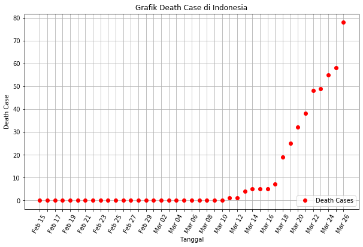

```python
plot_death_data(indonesia)
```

```python
print(indonesia['death_cases']['y'][0:26])
print(indonesia['death_cases']['x'][25])
```

```
[0 0 0 0 0 0 0 0 0 0 0 0 0 0 0 0 0 0 0 0 0 0 0 0 0 1]
Mar 11
```

### Persamaan Regresi Berpangkat untuk *Death Cases* di Indonesia

```
=== Persamaan Regresi Berpangkat pada death Cases setelah Mar 11 di Indonesia ===
            Persamaan Regresi = y = 4.925767720528715e-14(x^(9.498133187291986))
            Koefisien Korelasi = 0.9034500918332169
```

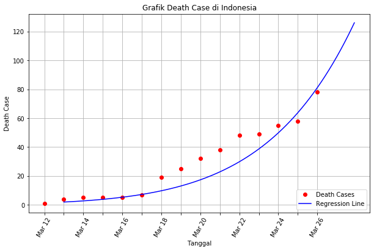

```python
indonesia_dc_p = regresi_death_berpangkat(indonesia, 'after', 'Mar 11')
```

### Persamaan Regresi Eksponensial untuk *Death Cases* di indonesia

```
=== Persamaan Regresi Eksponensial pada Death Cases setelah Mar 11 di Indonesia ===
            Persamaan Regresi = y = 0.0012e^(0.2798x)
            Koefisien Korelasi = 0.8316336942117888
```

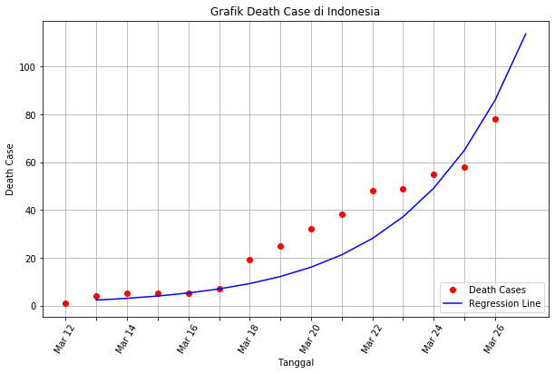

```python
indonesia_dc_e = regresi_death_eksponensial(indonesia, 'after', 'Mar 11')
```

### Persamaan Regresi Polinomial (orde 3) untuk *Death Cases* di Indonesia

```
=== Persamaan Regresi Polinomial pada Death Cases setelah Mar 11 di Indonesia ===
            Persamaan Regresi = y = 169.0414 + (-13.9040)x + (0.2829)x^2 + (0.0000)x^3
            Koefisien Korelasi = 0.9874213238450416
```

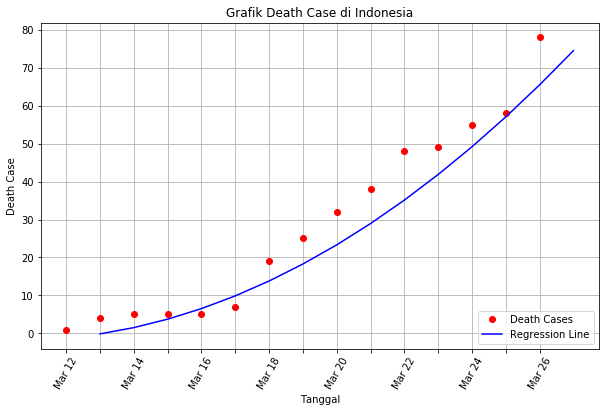

```python
indonesia_dc_po = regresi_death_polinomial(indonesia, 'after', 'Mar 11')
```

### Analisis kurva-kurva regresi pada *Death Cases* di Indonesia

```python
analisis('Death', indonesia_dc_p, indonesia_dc_e, indonesia_dc_po)
```

```
=== Death Cases hingga 26 Maret 2020 ===

        -Persamaan Regresi-
        Regresi Berpangkat: y = 4.925767720528715e-14(x^(9.498133187291986))
        Regresi Eksponensial: y = 0.0012e^(0.2798x)
        Regresi Polinomial orde 3: y = 169.0414 + (-13.9040)x + (0.2829)x^2 + (0.0000)x^3

        -Koefisien Korelasi-
        Regresi Berpangkat: 0.9035
        Regresi Eksponensial: 0.8316
        Regresi Polinomial orde 3: 0.9874
```

Dari data di atas, disimpulkan bahwa data *death cases* di Indonesia dapat diwakilkan oleh kurva regresi polinomial orde 3.

```python
kurva_negara['indonesia']['dc'] = indonesia_dc_po
```

## Ringkasan Negara, Fungsi Regresi, dan Koefisien Korelasinya

Berikut ini ringkasan Fungsi Regresi yang mewakili *Active Cases* tiap negara dan koefisien korelasinya:

```python
print("Fungsi Active Cases")
for key, values in kurva_negara.items():
    for tipe, atribut in values.items():
        if (tipe == 'ac'):
            print("""
== {} ==
Fungsi\t: {}
Koef. Korelasi\t: {} """.format(key, atribut['persamaan'], atribut['koefisien_korelasi']))
            print("Hasil f(x) bila x = 90: {}".format(atribut['fungsi'](90)))
```

```
Fungsi Active Cases

== china ==
Fungsi	: y = 108063.4835 + (-2034.6005)x + (4.9137)x^2 + (-0.0010)x^3
Koef. Korelasi	: 0.9812325634365296
Hasil f(x) bila x = 90: -35993.15592293341

== korsel ==
Fungsi	: y = -2698.0061 + (885.7491)x + (-22.9187)x^2 + (0.1429)x^3
Koef. Korelasi	: 0.9968768715243279
Hasil f(x) bila x = 90: -4479.852289023111

== italia ==
Fungsi	: y = 2735.2743 + (-617.9025)x + (15.6041)x^2 + (0.8557)x^3
Koef. Korelasi	: 0.9980581628362256
Hasil f(x) bila x = 90: 697325.0212131571

== iran ==
Fungsi	: y = -1192.6239 + (205.2842)x + (-5.8355)x^2 + (0.2868)x^3
Koef. Korelasi	: 0.9898880848757589
Hasil f(x) bila x = 90: 179102.0260192896

== spanyol ==
Fungsi	: y = 22090.8846 + (-2437.6071)x + (53.5164)x^2 + (0.4274)x^3
Koef. Korelasi	: 0.9891220511517428
Hasil f(x) bila x = 90: 547732.6833982572

== jerman ==
Fungsi	: y = 22083.6144 + (-2264.4532)x + (46.6215)x^2 + (0.4281)x^3
Koef. Korelasi	: 0.9939173203426981
Hasil f(x) bila x = 90: 508013.53799462866

== australia ==
Fungsi	: y = 0.3838e^(0.2199x)
Koef. Korelasi	: 0.9948595949184545
Hasil f(x) bila x = 90: 151240463.95498723

== amerika ==
Fungsi	: y = 10646.4097 + (-1963.2529)x + (46.2745)x^2 + (0.7026)x^3
Koef. Korelasi	: 0.9156458330892576
Hasil f(x) bila x = 90: 720994.6582123399

== indonesia ==
Fungsi	: y = 1195.0481 + (-105.9196)x + (2.3216)x^2 + (-0.0000)x^3
Koef. Korelasi	: 0.9965529089111412
Hasil f(x) bila x = 90: 10464.510347511881
```

Mengapa terjadi perbedaan fungsi pada tiap negara? Hal ini terjadi dikarenakan penanganan virus yang berbeda-beda pada setiap negara. Dilansir dar BBC, kunci negara-negara yang sukses menekan laju pertumbuhan virus ini adalah dengan terus menerus melakukan tes, sehingga jumlah pasien terinfeksi terus terupdate sehingga mendekati akurat. Bila data pasien terinfeksi sudah akurat, tentu akan mudah memonitor pasien-pasien sehingga dapat mengendalikan penyebaran virus. Selain itu, penangan pasien terinfeksi pada suatu negara juga menjadi faktor penentu kesuksesan suatu negara dalam menangani virus ini. Contohnya adalah melakukan isolasi kepada pasien terinfeksi. Selain tes dan penanganan pasien, kesiapan dan reaksi negara dalam menghadapi akibat dari virus juga menjadi faktor penentu keberhasilan dalam menekan laju virus ini. Kebijakan dan langkah-langkah strategis yang diambil oleh pemerintah suatu negara tentu akan sangat berpengaruh pada keberhasilan menghadapi virus corona ini. Contoh saja Amerika, dilansir dari Tagar.id, mereka lamban dalam mengambil langkah, dimana Presiden AS, Donald Trump baru menerapkan *physical distancing* pada 29 Maret 2020. Akibatnya, virus menyebar dengan cepat disana, bahkan kini Amerika menjadi negara dengan jumlah pasien terinfeksi paling banyak.

Selain negara, perilaku masyarakat juga berperan penting dalam menekan laju penyebaran virus. Dilansir dari health24.com, penerapan *social distancing* yang sangat ketat di Wuhan menjadi kunci keberhasilan mereka menurunkan laju pertumbuhan virus secara drastis. Kemudian, perilaku hidup bersih masyarakat juga menjadi salah satu faktor penting dalam menekan laju pertumbuhan virus ini. Selalu mencuci tangan, jaga jarak fisik dengan orang lain, merupakan contoh perilaku hidup higienis yang perlu diterapkan untuk menekan laju pertumbuhan virus ini.

Sumber:

https://www.tagar.id/4-faktor-tingginya-angka-korban-virus-corona-di-as https://www.bbc.com/indonesia/majalah-51974072 https://www.health24.com/Medical/Infectious-diseases/Coronavirus/wuhan-study-shows-how-social-distancing-to-curb-the-spread-of-coronavirus-is-saving-lives-20200327-2

Berikut ini ringkasan Fungsi Regresi yang mewakili *Death Cases* tiap negara dan koefisien korelasinya:

```python
print("Fungsi Death Cases")
for key, values in kurva_negara.items():
    for tipe, atribut in values.items():
        if (tipe == 'dc'):
            print("""
== {} ==
Fungsi\t: {}
Koef. Korelasi\t: {} """.format(key, atribut['persamaan'], atribut['koefisien_korelasi']))
            print("Hasil f(x) bila x = 4: {}".format(atribut['fungsi'](4)))
```

```
Fungsi Death Cases

== china ==
Fungsi	: y = 916.3974521664856(x^(0.31253719394663365))
Koef. Korelasi	: 0.9636381920798194
Hasil f(x) bila x = 4: 1413.3509440886992

== korsel ==
Fungsi	: y = -5.7704 + (1.0246)x + (0.0551)x^2 + (0.0000)x^3
Koef. Korelasi	: 0.99728378726209
Hasil f(x) bila x = 4: -0.7905318424331857

== italia ==
Fungsi	: y = 1811.5441 + (-208.8578)x + (2.9339)x^2 + (0.1427)x^3
Koef. Korelasi	: 0.9966978029746382
Hasil f(x) bila x = 4: 1032.188965196279

== iran ==
Fungsi	: y = 445.8963 + (-76.6129)x + (2.9388)x^2 + (-0.0000)x^3
Koef. Korelasi	: 0.9960113779954755
Hasil f(x) bila x = 4: 186.4626979690192

== spanyol ==
Fungsi	: y = 8589.5360 + (-720.6674)x + (14.7438)x^2 + (-0.0000)x^3
Koef. Korelasi	: 0.9797319455985405
Hasil f(x) bila x = 4: 5942.763716164716

== jerman ==
Fungsi	: y = 1092.6520 + (-78.5479)x + (1.4075)x^2 + (-0.0000)x^3
Koef. Korelasi	: 0.9879194785551578
Hasil f(x) bila x = 4: 800.980649826261

== australia ==
Fungsi	: y = 5.6691 + (-0.5028)x + (0.0153)x^2 + (-0.0000)x^3
Koef. Korelasi	: 0.9623820315991564
Hasil f(x) bila x = 4: 3.9032790375473883

== amerika ==
Fungsi	: y = 0.0762e^(0.2343x)
Koef. Korelasi	: 0.9905145918910959
Hasil f(x) bila x = 4: 0.19460375422092777

== indonesia ==
Fungsi	: y = 169.0414 + (-13.9040)x + (0.2829)x^2 + (0.0000)x^3
Koef. Korelasi	: 0.9874213238450416
Hasil f(x) bila x = 4: 117.9516526510329
```

Sama halnya dengan fungsi regresi untuk *active case* , fungsi regresi untuk *death cases* juga berbeda-beda pada tiap negara. Ada negara dengan banyak *active case* , namun memiliki tingkat recovery yang tinggi sehingga memiliki sedikit *death case* . Faktor utama yang mempengaruhi perbedaan jumlah *death case* pada tiap negara adalah kesiapan negara dalam menghadapi virus ini. Dilansir dari npr.com, Kesiapan negara dari sisi medis sangat mempengaruhi tingkat fatalitas virus corona di suatu negara.

Misalnya di italia, mereka menerapkan tes hanya untuk pasien yang menunjukkan gejala parah saja. Akibatnya, tingkat kematian akibat corona di sana mencapai 10%. Adapun Korea, yang memiliki tingkat kematian karena virus corona sebesar 2,5%, mereka menerapkan tes kepada semua orang, baik menunjukkan gejala maupun tidak.

Selain itu, menurut Mary Bushman, peneliti di Pusat Dinamika Penyakit Menular Harvard, faktor lain yang meningkatkan *fatality rate* dari virus corona ini adalah karakteristik dari populasi yang terinfeksi. Di negara bagian Washington, kata Bushman, kasus pertama muncul di panti jompo, dan 34 dari 81 pasien terinfeksi meninggal, sehingga menghasilkan *fatality rate* sebesar 42%. Namun bila diukur di luar, maka tingkat fatalitas dari virus ini tentu akan lebih rendah.

Fasilitas kesehatan yang tersedia di suatu negara juga menjadi faktor penentu tingkat fatalitas. Membludaknya jumlah pasien terinfeksi dan sedikitnya kapasitas rumah sakit merupakan sebab tingginya tingkat fatalitas corona di Wuhan pada awal virus corona muncul, hingga akhirnya Wuhan membuat banyak rumah sakit darurat dan dapat menekan tingkat fatalitas dengan drastis.

Sumber:

https://www.health24.com/Medical/Infectious-diseases/Coronavirus/wuhan-study-shows-how-social-distancing-to-curb-the-spread-of-coronavirus-is-saving-lives-20200327-2 https://www.npr.org/sections/goatsandsoda/2020/03/27/821958435/why-death-rates-from-coronavirus-can-be-deceiving

### Indonesia, Paling Mirip dengan Negara Mana?

Saya mencoba mencari negara mana yang fungsi regresi active case dan fungsi regresi death case nya akan bernilai berdekatan dengan Indonesia apabila diinput suatu angka tertentu (tentunya yang tidak terlalu besar karena fungsi tidak akan akurat). saya pun menginputkan angka 3 dan berikut hasilnya:

```python
hasil_fac = []
hasil_fdc = []
negara_hasilfac = {}
negara_hasilfdc = {}

for key, values in kurva_negara.items():
    for a, b in values.items():
        if (a == 'ac'):
            hasil = b['fungsi'](3)
            hasil_fac.append(hasil)
            negara_hasilfac[hasil]=key
print()
for key, values in kurva_negara.items():
    for a, b in values.items():
        if (a == 'dc'):
            hasil = b['fungsi'](3)
            hasil_fdc.append(hasil)
            negara_hasilfdc[hasil]=key
hasil_fac.sort()
hasil_fdc.sort()
hasil_fac_indonesia = kurva_negara['indonesia']['ac']['fungsi'](3)
hasil_fdc_indonesia = kurva_negara['indonesia']['dc']['fungsi'](3)
index = hasil_fac.index(hasil_fac_indonesia)
print("Dengan nilai x = 3, hasil Fungsi kurva active cases indonesia, yaitu {},\ndi atas negara {}, dengan hasil kurva {},\ndan di bawah negara {} dengan hasil kurva {}"\
      .format(hasil_fac_indonesia, negara_hasilfac[hasil_fac[index-1]], hasil_fac[index-1], negara_hasilfac[hasil_fac[index+1]], hasil_fac[index+1]))
print()
print("Dengan nilai x = 3, hasil Fungsi kurva death cases indonesia, yaitu {},\ndi atas negara {}, dengan hasil kurva {},\ndan di bawah negara {} dengan hasil kurva {}"\
      .format(hasil_fdc_indonesia, negara_hasilfdc[hasil_fdc[index-1]], hasil_fdc[index-1], negara_hasilfdc[hasil_fdc[index+1]], hasil_fdc[index+1]))
```

```
Dengan nilai x = 3, hasil Fungsi kurva active cases indonesia, yaitu 898.1834882910788,
di atas negara australia, dengan hasil kurva 0.7423562400468305,
dan di bawah negara italia dengan hasil kurva 1045.107495157172

Dengan nilai x = 3, hasil Fungsi kurva death cases indonesia, yaitu 129.8754503779367,
di atas negara australia, dengan hasil kurva 4.298727119201862,
dan di bawah negara iran dengan hasil kurva 242.5056498034382
```

Tentu hasil perhitungan di atas belum dapat menggambarkan secara real negara mana yang situasinya mirip dengan Indonesia. Namun, bila kita lihat situasi di Indonesia sekarang, situasi di Indonesia ini mirip dengan negara Italia saat kasus di sana masih belum meledak seperti sekarang. Dilansir dari kompas.com, pada awal kemunculan virus corona di Italia, masyarakat dan pemerintah masih terkesan meragukan apakah COVID-19 ini benar-benar berbahaya. Tes Corona pun hanya dilakukan terhadap orang yang menunjukkan gejala parah. Lockdown terhadap provinsi yang terdampak pun tidak dilakukan, yang dilakukan hanya membatasi ruang gerak masyarakat, namun tidak signifikan. Akibatnya, virus corona berkembang pesat di Italia, yang saat ini menjadi negara kedua dengan jumlah pasien corona terbanyak. Situasi di Indonesia saat ini pun begitu, pemerintah terkesan lamban dan ragu-ragu dalam mengambil kebijakan publik, masih terdapat orang-orang yang bepergian keluar kota, minimnya tes yang dilakukan sehingga kasus yang sebenarnya bisa jadi jauh lebih besar dari kasus yang terkonfirmasi, minimnya fasilitas kesehatan, serta kesadaran sebagian masyarakat yang masih meremehkan bahaya COVID 19 ini. Bila situasi ini terus berlanjut, bukan tidak mungkin Indonesia akan menjadi seperti Italia.

Sumber:

https://www.kompas.com/sains/read/2020/03/31/163300323/atasi-virus-corona-ini-pelajaran-dari-strategi-di-italia-hingga-china https://kumparan.com/kumparansains/mengapa-penyebaran-virus-corona-di-italia-terjadi-begitu-cepat-1t38hgu54ms